# Biopsychology versus Social Psychology: Better Predictor of Mental Health?

## Abstract

My research question is whether social factors or biological factors are a better predictor of mental health. This is inspired by the different perspectives of psychology, and specifically about debating the perspective between biopsychology and social psychology. I grouped the data into biological factors (gender, body mass index, how many sedentary minutes they have a day, whether they have high blood pressure or cholesterol, whether they have anemia, whether they are overweight, and how many hours of sleep they receive each night) and social factors (education, family income to poverty ratio, race, self image, monthly poverty index, and the number of hours they work). The population of the survey is adults over the age of 20 living in the U.S., and I used the data collected between the years 2013-2020. The result was that the models trained on social factors had a significantly higher accuracy than the models trained on biological factors. This suggests that the problem with mental health is not based on the environment around us individually, but the social environment imposed on us by the people around us. Rather than look at each individual separately, we should take into account the entire population as a whole.

## Background

My research question is determining whether social factors, like their education, family income to poverty ratio, race, self image, monthly poverty index, and the number of hours they work, or biological factors, like their gender, body mass index, how many sedentary minutes they have a day, whether they have high blood pressure or cholesterol, whether they have anemia, whether they are overweight, and how many hours of sleep they receive each night, are a better predictor of their overall mental health. My hypothesis is that there is a difference between the two factors, and one set of factors will be better at predicting one’s mental health than the other set.

This is important to see because it allows us to narrow down on a set of factors and focus our resources and attention that would make the most impact on people. It would allow the process to be more time efficient as well as more cost efficient for the overall population, and serve as a starting point. The data is from the National Health and Nutrition Examination Survey from 2013-2020, conducted by the Centers of Disease Control and Prevention on people living in the United States.

## Results

**Figure 1: Monthly poverty index**

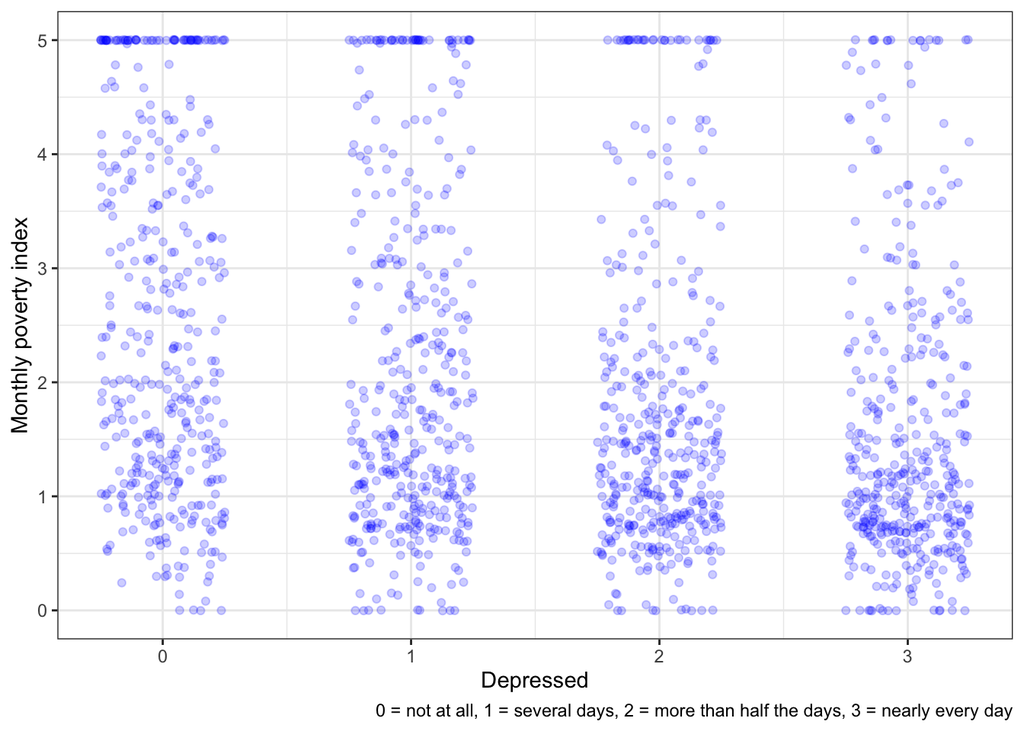

Because there was an overwhelming amount of people who answer ‘0’ on this question, I filtered out the noise by selecting 400 people randomly from each answer. Looking at the graph, you can tell that the distribution of monthly poverty index varies depending on the answer that people chose. As the rate of depressive episodes over the past two weeks increase, so does the concentration of people who are lower on the monthly poverty index. The distribution also becomes more polarized. As you can see at the distribution of people who answered ‘nearly every day,’ clusters of people were either high or low on the monthly poverty index, with relatively less people who are in between. It’s also interesting to see that there the greatest number of people who are ranked highly on the monthly poverty index answered ‘0,’ or not at all, to this question.

**Figure 2: Hours of sleep**

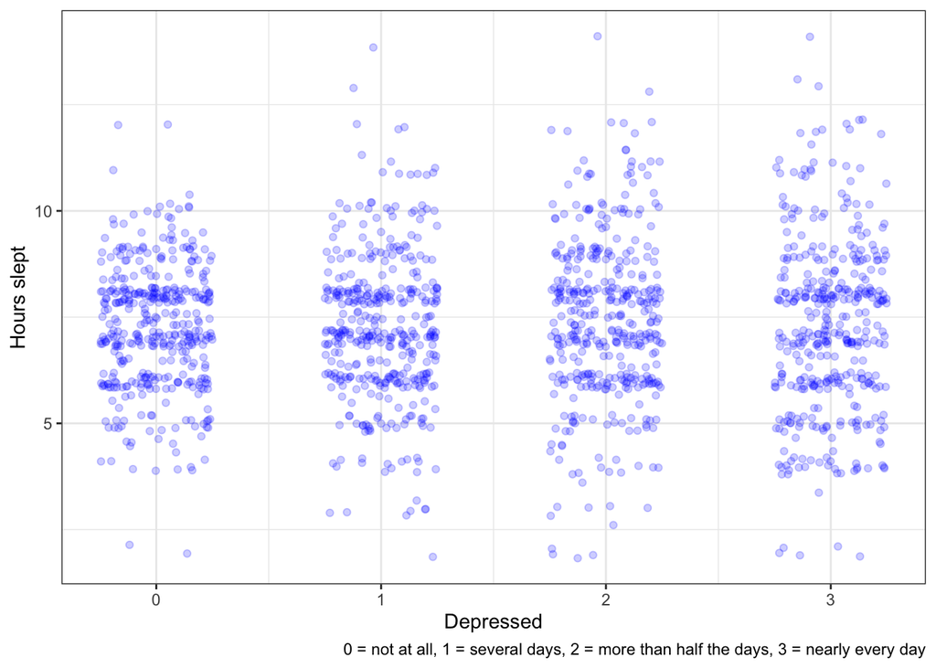

Here is another graph with an interesting distribution. You can see with the people who answered ‘not at all,’ the number of hours they slept are very consistent, with a majority of people sleeping between 5-10 hours each night. However, with the people who answered others than ‘not at all,’ the distribution of the hours they sleep each night becomes more haphazard, and have a larger variation from the normal distribution. This may be the result of a disrupted sleep cycle and irregular sleeping schedules.

**Figure 3: Gradient Boosting Tree for Biological Factors**

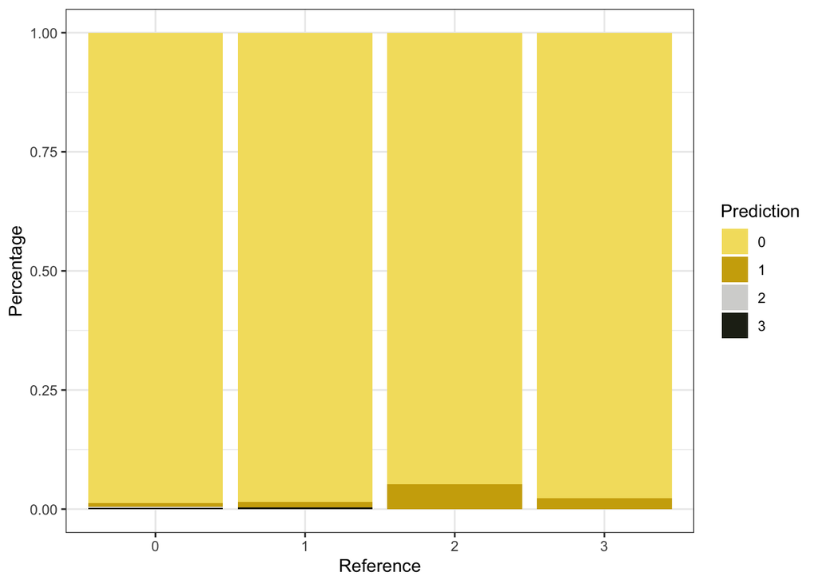

**Figure 4: Random Forest for Biological Factors**

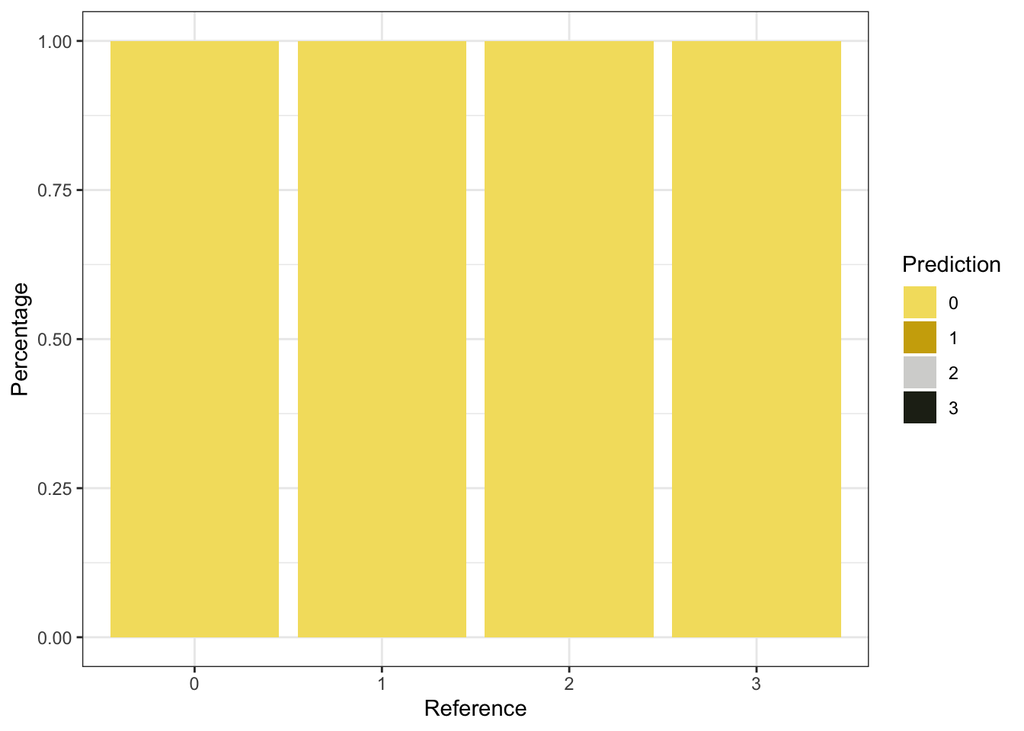

**Figure 5: Most Important Biological Factors**

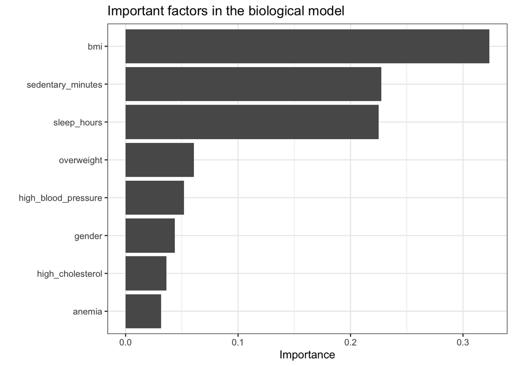

For what it’s worth, the most important biological factor in the models is a person’s body mass index. However, it may not be an accurate depiction because the models mostly guessed ‘0,’ which indicated that the models required no analysis of its factors.

**Figure 6: Gradient Boosting Tree for Social Factors**

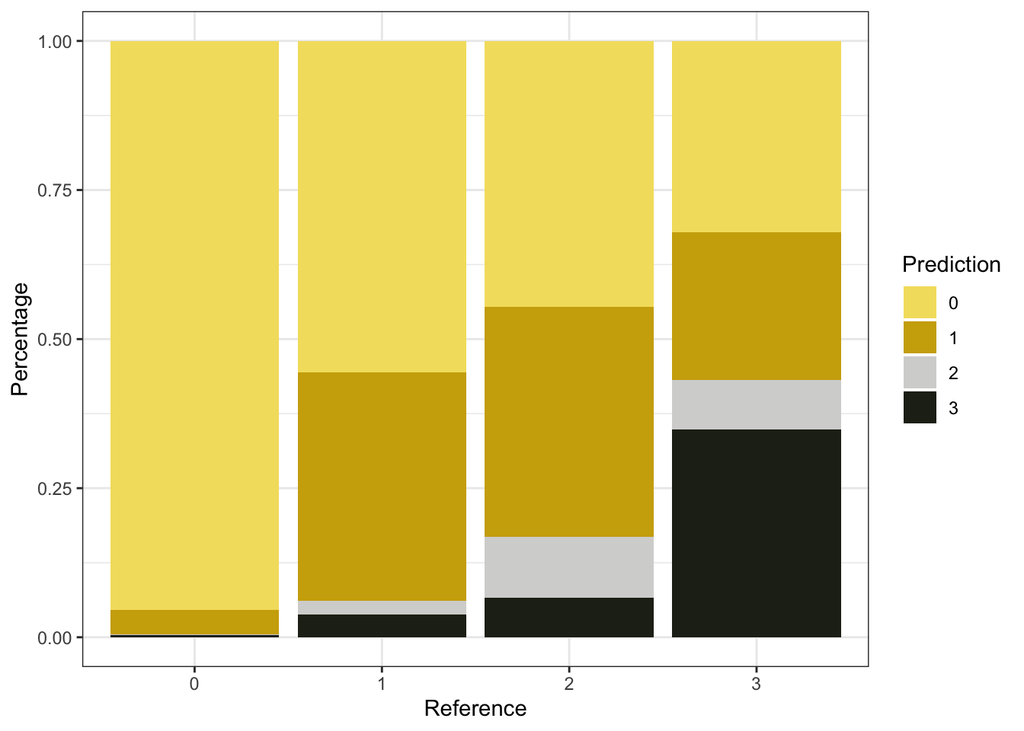

The gradient boosting tree trained on social factors is much more accurate than the gradient boosting tree trained on biological factors. You can see that although the model is still guessing ‘0’ most of the time, it at least is able to detect a level of inconsistency between the answers to determine the presence of a problem in one’s mental health, but not be able to exactly pinpoint the severity. A person who answer ‘2’ to the question is the least likely to be guessed correctly by the model, which simply might be because there is a lack of people who answered that way on the survey.

**Figure 7: Random Forest for Social Factors**

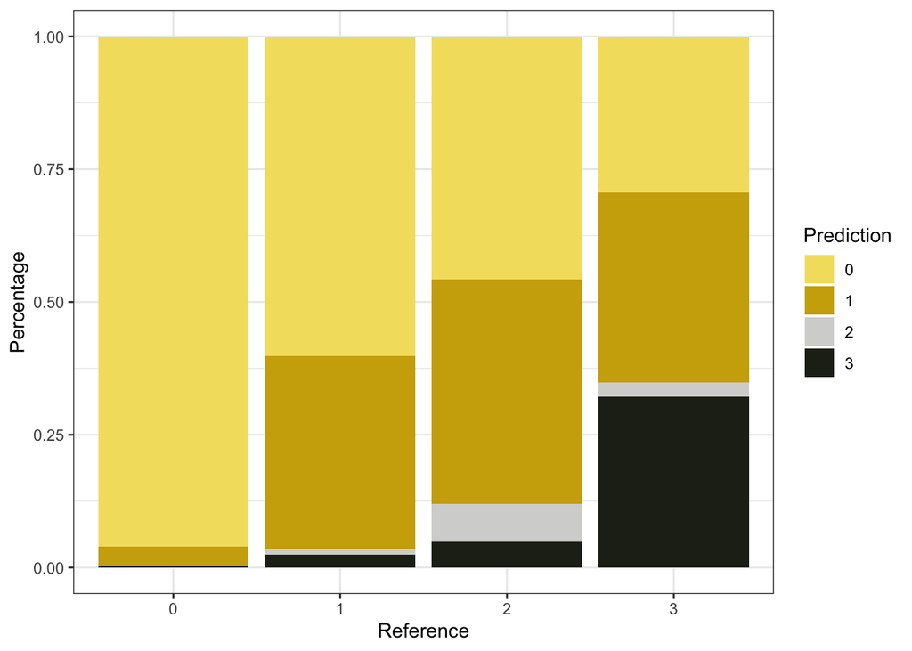

The random forest model trained on social factors has roughly the same accuracy as the gradient boosting tree. Only this time, the model predicted even less 2’s, and instead compensated by guessing ‘1’ more times.

**Figure 8: Most Important Social Factors**

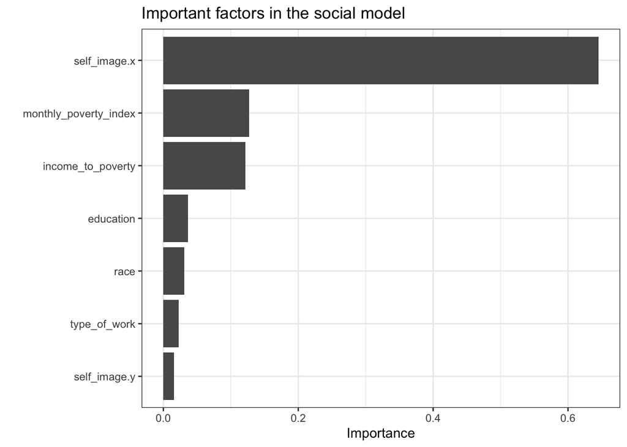

As shown in the chart above, the most significant factor by a large margin used in the models is a person’s self image. Trailing behind are the family income to poverty ratio and the monthly poverty index, which factored into the model’s decision a little over 10% for each.

## Discussion

However, it is important to mention that this is merely a suggestion, and does not determine a causal relationship between social factors and mental health issues. The method I used, of training different models to determine the accuracy, is also flawed in that these models do not conclude a definite relationship between the two factors. The data is also flawed because it only accounts for people interviewed between 2013-2020 and older than 21. Also, the way that I defined a mental health issue was how they answered the question, “[Over the last 2 weeks, how often have you been bothered by the following problems:] feeling down, depressed, or hopeless?” Of course, two weeks is in no way a long enough period of time to determine the extent of one’s mental health, and has the potential to be impacted by extraneous factors. Another notable factor missing from biological factors is their family history of depression, which would’ve added a new insight into an individual.

The next logical step of this research is to investigate the best combination of both biological factors and social factors that would lend to the highest accuracy score of its trained models.

## Code and Data Availability

You can see the code here: https://github.com/the-codingschool/DSRP-2023-DiDonato/tree/main/Laurel

All the data comes from the CDC website:

- 2017-2020: https://wwwn.cdc.gov/nchs/nhanes/continuousnhanes/default.aspx?Cycle=2017-2020
- 2015-2016: https://wwwn.cdc.gov/nchs/nhanes/continuousnhanes/default.aspx?BeginYear=2015
- 2013-2014: https://wwwn.cdc.gov/nchs/nhanes/continuousnhanes/default.aspx?BeginYear=2013

## Acknowledgements

I would like to acknowledge Yijia Wang and AJ DiDonato for providing feedback on my project, as well as Sarah Parker for teaching me all I know about R right now and Delaney Rice for being the organizer of this program.